# Analysis of longitudinal data

## Data description

For this week assignment I use two datasets:

1. BPRS - Brief Psychiatric Rating Scale Measurements from 40 Subjects
2. RATS - Body Weights of Rats Recorded Over a 9-Week Period

## Chapter 8 of MABS using the RATS

```r
library(tidyr)
library(dplyr)
```

```r
library(ggplot2)

RATS <- read.table("https://raw.githubusercontent.com/KimmoVehkalahti/MABS/master/Examples/data/rats.txt",
                   sep  ="", header = T)
RATS$ID <- factor(RATS$ID)
RATS$Group <- factor(RATS$Group)
RATSL <- read.csv("~/IODS-project/data/RATSL.csv")
RATSL$ID <- factor(RATSL$ID)
RATSL$Group <- factor(RATSL$Group)
```

First, let’s plot the RATS values for all 16 rats, differentiating between the study groups.The weight of almost all the rats is increasing over the research period. The animals that have higher weight values at the beginning tend to have higher values throughout the study. There are also substantial differences between rats.

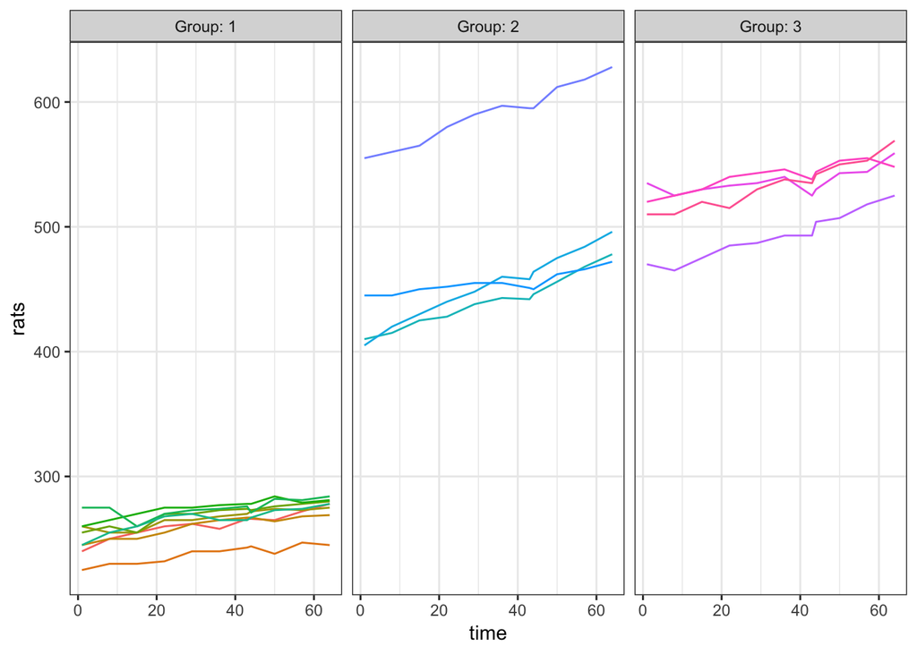

```r
p1 <- ggplot(RATSL, aes(x = time, y = rats, color = ID))
p2 <- p1 + geom_line() + scale_linetype_manual(values = rep(1:10, times=4))
p3 <- p2 + facet_grid(. ~ Group, labeller = label_both)
p4 <- p3 + theme_bw() + theme(legend.position = "none")
p5 <- p4 + theme(panel.grid.minor.y = element_blank())
p6 <- p5 + scale_y_continuous(limits = c(min(RATSL$rats), max(RATSL$rats)))
p6
```

Let’s scale the data by subtracting the mean from the original observation and then dividing by the corresponding standard deviation.

```r
# Standardise the scores:
RATSL <- RATSL %>%
  group_by(time) %>%
  mutate(stdrats = (rats - mean(rats))/sd(rats) ) %>%
  ungroup()
glimpse(RATSL)
```

```
## Observations: 176
## Variables: 7
## $ ID      <fct> 1, 2, 3, 4, 5, 6, 7, 8, 9, 10, 11, 12, 13, 14, 15, 16, 1…
## $ Group   <fct> 1, 1, 1, 1, 1, 1, 1, 1, 2, 2, 2, 2, 3, 3, 3, 3, 1, 1, 1,…
## $ times   <fct> WD1, WD1, WD1, WD1, WD1, WD1, WD1, WD1, WD1, WD1, WD1, W…
## $ rats    <int> 240, 225, 245, 260, 255, 260, 275, 245, 410, 405, 445, 5…
## $ time    <int> 1, 1, 1, 1, 1, 1, 1, 1, 1, 1, 1, 1, 1, 1, 1, 1, 8, 8, 8,…
## $ stdbprs <dbl> -1.0011429, -1.1203857, -0.9613953, -0.8421525, -0.88190…
## $ stdrats <dbl> -1.0011429, -1.1203857, -0.9613953, -0.8421525, -0.88190…
```

Now I plot scaled data separated by group again.

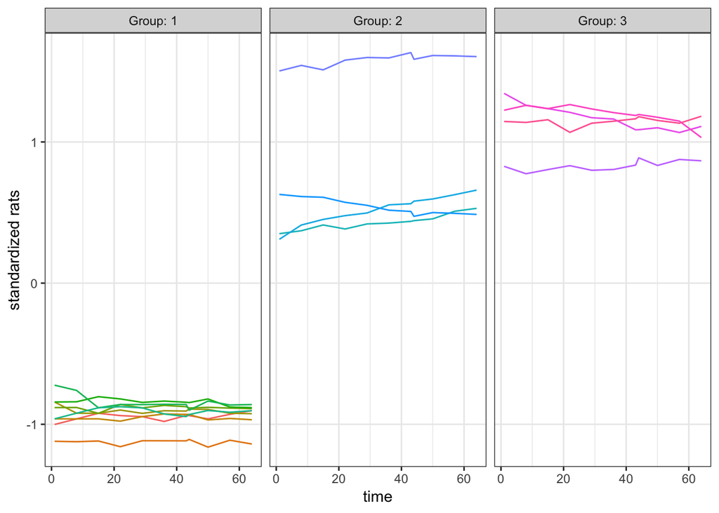

```r
p1 <- ggplot(RATSL, aes(x = time, y = stdrats, color = ID))
p2 <- p1 + geom_line() + scale_linetype_manual(values = rep(1:10, times=4))
p3 <- p2 + facet_grid(. ~ Group, labeller = label_both)
p4 <- p3 + theme_bw() + theme(legend.position = "none")
p5 <- p4 + theme(panel.grid.minor.y = element_blank())
p6 <- p5 + scale_y_continuous(name = "standardized rats")
p6
```

The mean profiles of the three groups suggest that there is a big difference between them with respect to the mean weight values.

```r
# Number of times, baseline (time 1) included:
n <- RATSL$time %>% unique() %>% length()
```

Now we will analyze the summary dataset.

```r
# Make a summary data:
RATSS <- RATSL %>%
  group_by(Group, time) %>%
  summarise(mean=mean(rats), se=sd(rats)/sqrt(n) ) %>%
  ungroup()
glimpse(RATSS)
```

```
## Observations: 33
## Variables: 4
## $ Group <fct> 1, 1, 1, 1, 1, 1, 1, 1, 1, 1, 1, 2, 2, 2, 2, 2, 2, 2, 2, 2…
## $ time  <int> 1, 8, 15, 22, 29, 36, 43, 44, 50, 57, 64, 1, 8, 15, 22, 29…
## $ mean  <dbl> 250.625, 255.000, 254.375, 261.875, 264.625, 265.000, 267.…
## $ se    <dbl> 4.589478, 3.947710, 3.460116, 4.100800, 3.333956, 3.552939…
```

The following graph shows the average profile for each study group along with some indication of the variation of the observations at each time point. There is no overlap in the mean profiles of the three groups, meaning there is a significant difference between them with respect to the mean weight values.

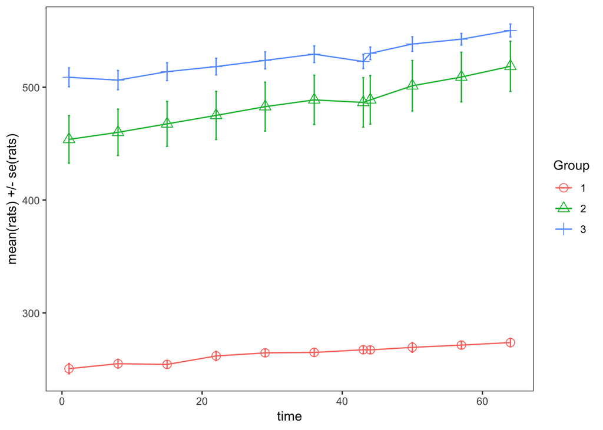

```r
p1 <- ggplot(RATSS, aes(x = time, y = mean, color = Group, shape = Group))
p2 <- p1 + geom_line() + scale_linetype_manual(values = c(1,2,3))
p3 <- p2 + geom_point(size=3) + scale_shape_manual(values = c(1,2,3))
p4 <- p3 + geom_errorbar(aes(ymin=mean-se, ymax=mean+se), width=0.3)
p5 <- p4 + theme_bw() + theme(panel.grid.major = element_blank(), panel.grid.minor = element_blank())
p6 <- p5 + scale_y_continuous(name = "mean(rats) +/- se(rats)")
p6
```

We can also investigate the mean profiles with box plots of the observations at each time point. The plot suggests the presence of some possible “outliers” at most time points and indicates again the general increase in weight values over the nine weeks of the study in all the groups.

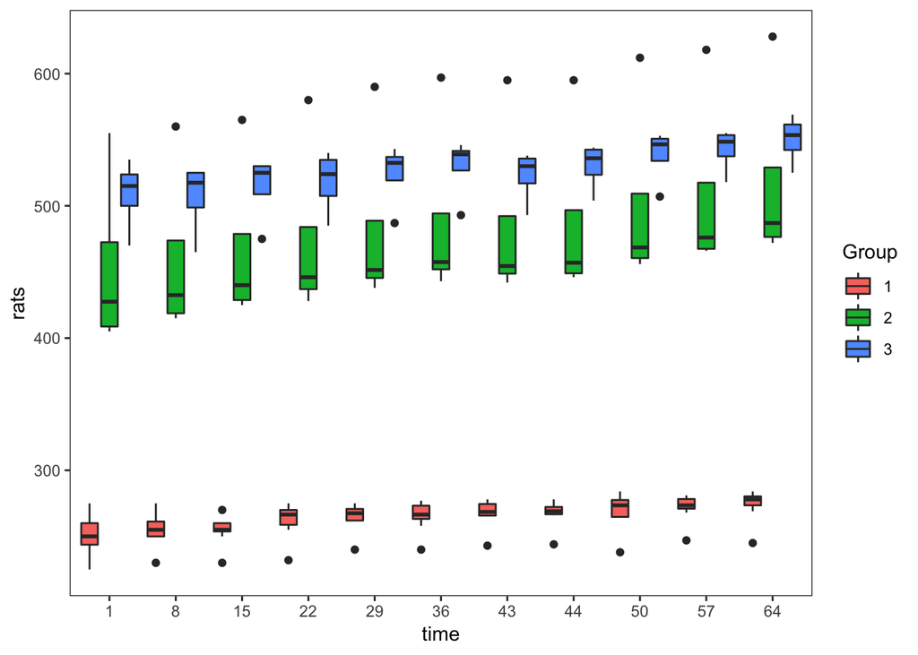

```r
p1 <- ggplot(RATSL, aes(x = factor(time), y = rats, fill = Group))
p2 <- p1 + geom_boxplot(position = position_dodge(width = 0.9))
p3 <- p2 + theme_bw() + theme(panel.grid.major = element_blank(), panel.grid.minor = element_blank())
p4 <- p3 + scale_x_discrete(name = "time")
p4
```

```r
RATS11S <- RATSL %>%
  filter(time > 1) %>%
  group_by(Group, ID) %>%
  summarise(mean=mean(rats) ) %>%
  ungroup()
glimpse(RATS11S)
```

```
## Observations: 16
## Variables: 3
## $ Group <fct> 1, 1, 1, 1, 1, 1, 1, 1, 2, 2, 2, 2, 3, 3, 3, 3
## $ ID    <fct> 1, 2, 3, 4, 5, 6, 7, 8, 9, 10, 11, 12, 13, 14, 15, 16
## $ mean  <dbl> 263.2, 238.9, 261.7, 267.2, 270.9, 276.2, 274.6, 267.5, 44…
```

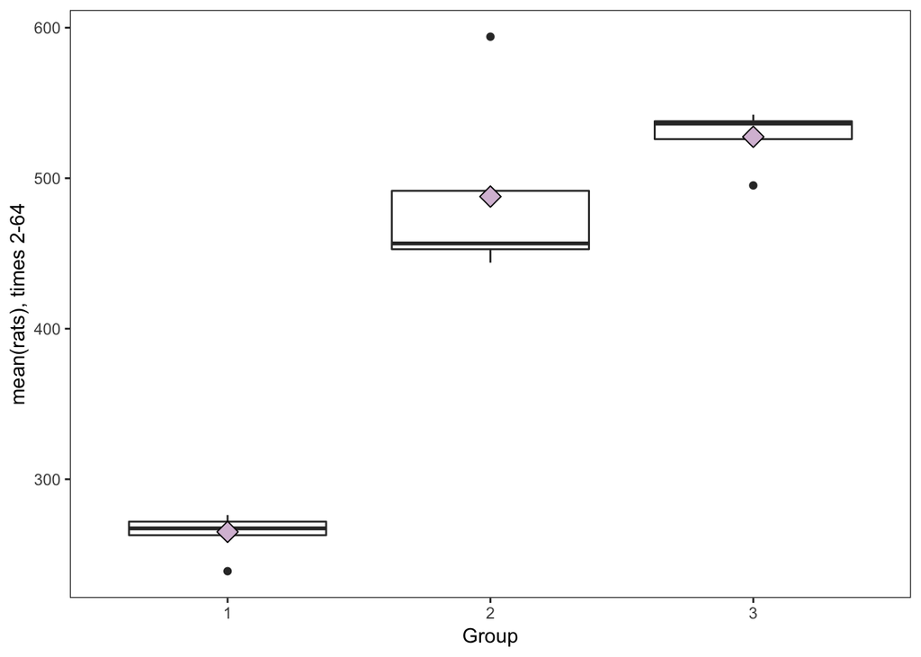

```r
p1 <- ggplot(RATS11S, aes(x = Group, y = mean))
p2 <- p1 + geom_boxplot()
p3 <- p2 + theme_bw() + theme(panel.grid.major = element_blank(), panel.grid.minor = element_blank())
p4 <- p3 + stat_summary(fun.y = "mean", geom = "point", shape=23, size=4, fill = "thistle")
p5 <- p4 + scale_y_continuous(name = "mean(rats), times 2-64")
p5
```

There are outliers in each group, however the box plot of the second group is most severely skewed by it. So, we shall remove an observation where mean RATS score is over 550.

```r
RATS11S1 <- RATS11S %>%
  filter(mean < 550)
glimpse(RATS11S1)
```

```
## Observations: 15
## Variables: 3
## $ Group <fct> 1, 1, 1, 1, 1, 1, 1, 1, 2, 2, 2, 3, 3, 3, 3
## $ ID    <fct> 1, 2, 3, 4, 5, 6, 7, 8, 9, 10, 11, 13, 14, 15, 16
## $ mean  <dbl> 263.2, 238.9, 261.7, 267.2, 270.9, 276.2, 274.6, 267.5, 44…
```

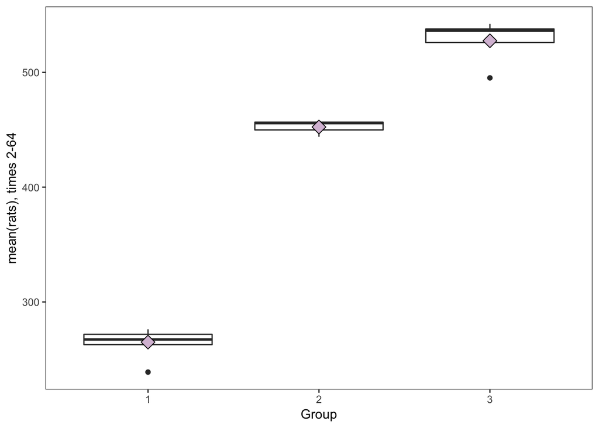

```r
p1 <- ggplot(RATS11S1, aes(x = Group, y = mean))
p2 <- p1 + geom_boxplot()
p3 <- p2 + theme_bw() + theme(panel.grid.major = element_blank(), panel.grid.minor = element_blank())
p4 <- p3 + stat_summary(fun.y = "mean", geom = "point", shape=23, size=4, fill = "thistle")
p5 <- p4 + scale_y_continuous(name = "mean(rats), times 2-64")
p5
```

Although the mean difference is quite obvious from the graph, we can formally test for it implementing analysis of variance (ANOVA).

```r
# ANOVA instead of two-sided t-test
summary(aov(mean ~ Group, data = RATS11S1))
```

```
##             Df Sum Sq Mean Sq F value   Pr(>F)
## Group        2 207659  103830   501.8 2.72e-12 ***
## Residuals   12   2483     207
## ---
## Signif. codes:  0 '***' 0.001 '**' 0.01 '*' 0.05 '.' 0.1 ' ' 1
```

P-value is close to zero, which suggests that differences are significant indeed. But we still don’t know between which groups exactly. So, I will subset the dataset and compare groups separately.

```r
RATS11S1gr12 <- RATS11S1[which(RATS11S1$Group =='1' | RATS11S1$Group =='2'), ]
t.test(mean ~ Group, data = RATS11S1gr12, var.equal = TRUE)
```

```
##
##  Two Sample t-test
##
## data:  mean by Group
## t = -25.399, df = 9, p-value = 1.094e-09
## alternative hypothesis: true difference in means is not equal to 0
## 95 percent confidence interval:
##  -204.0633 -170.6867
## sample estimates:
## mean in group 1 mean in group 2
##         265.025         452.400
```

**The difference between means in Group 1 and Group 2 is highly significant**.

```r
RATS11S1gr13 <- RATS11S1[which(RATS11S1$Group =='1' | RATS11S1$Group =='3'), ]
t.test(mean ~ Group, data = RATS11S1gr13, var.equal = TRUE)
```

```
##
##  Two Sample t-test
##
## data:  mean by Group
## t = -27.824, df = 10, p-value = 8.345e-11
## alternative hypothesis: true difference in means is not equal to 0
## 95 percent confidence interval:
##  -283.4943 -241.4557
## sample estimates:
## mean in group 1 mean in group 3
##         265.025         527.500
```

**The difference between means in Group 1 and Group 3 is highly significant**.

```r
RATS11S1gr23 <- RATS11S1[which(RATS11S1$Group =='2' | RATS11S1$Group =='3'), ]
t.test(mean ~ Group, data = RATS11S1gr23, var.equal = TRUE)
```

```
##
##  Two Sample t-test
##
## data:  mean by Group
## t = -5.632, df = 5, p-value = 0.002446
## alternative hypothesis: true difference in means is not equal to 0
## 95 percent confidence interval:
##  -109.37769  -40.82231
## sample estimates:
## mean in group 2 mean in group 3
##           452.4           527.5
```

**The difference between means in Group 2 and Group 3 is significant**.

Baseline measurements of the outcome variable in a longitudinal study are often correlated with the chosen summary measure and can boost our precision score in an analysis of covariance. We will use the RATS value corresponding to the first week period as the baseline covariate.

```r
# Add the baseline from the original data as a new variable to the summary data:
baseline <- RATS$WD1
RATS11S2 <- RATS11S %>%
  mutate(baseline)
```

```r
# Fit the ANCOVA model and see the results:
fit <- lm(mean ~ baseline + Group, data = RATS11S2)
summary(fit)
```

```
##
## Call:
## lm(formula = mean ~ baseline + Group, data = RATS11S2)
##
## Residuals:
##     Min      1Q  Median      3Q     Max
## -23.905  -4.194   2.190   7.577  14.800
##
## Coefficients:
##             Estimate Std. Error t value Pr(>|t|)
## (Intercept) 33.16375   21.87657   1.516   0.1554
## baseline     0.92513    0.08572  10.793 1.56e-07 ***
## Group2      34.85753   18.82308   1.852   0.0888 .
## Group3      23.67526   23.25324   1.018   0.3287
## ---
## Signif. codes:  0 '***' 0.001 '**' 0.01 '*' 0.05 '.' 0.1 ' ' 1
##
## Residual standard error: 11.68 on 12 degrees of freedom
## Multiple R-squared:  0.9936, Adjusted R-squared:  0.992
## F-statistic: 622.1 on 3 and 12 DF,  p-value: 1.989e-13
```

```r
anova(fit)
```

```
## Analysis of Variance Table
##
## Response: mean
##           Df Sum Sq Mean Sq   F value   Pr(>F)
## baseline   1 253625  253625 1859.8201 1.57e-14 ***
## Group      2    879     439    3.2219  0.07586 .
## Residuals 12   1636     136
## ---
## Signif. codes:  0 '***' 0.001 '**' 0.01 '*' 0.05 '.' 0.1 ' ' 1
```

## Chapter 9 of MABS using the BPRS

```r
BPRS <- read.table("https://raw.githubusercontent.com/KimmoVehkalahti/MABS/master/Examples/data/BPRS.txt",
                   sep  =" ", header = T)
# subject numbers in different treatment groups are similar
# so both groups have subject #1, subject #2 etc
# we have to change it, since those are different individuals actually
BPRS$subject <- seq(1, 40)
BPRS$treatment <- factor(BPRS$treatment)
BPRS$subject <- factor(BPRS$subject)
BPRSL <-  BPRS %>% gather(key = weeks, value = bprs, -treatment, -subject)
BPRSL$treatment <- factor(BPRSL$treatment)
BPRSL$subject <- factor(BPRSL$subject)
BPRSL <-  BPRSL %>% mutate(week = as.integer(substr(weeks,5, 5)))
```

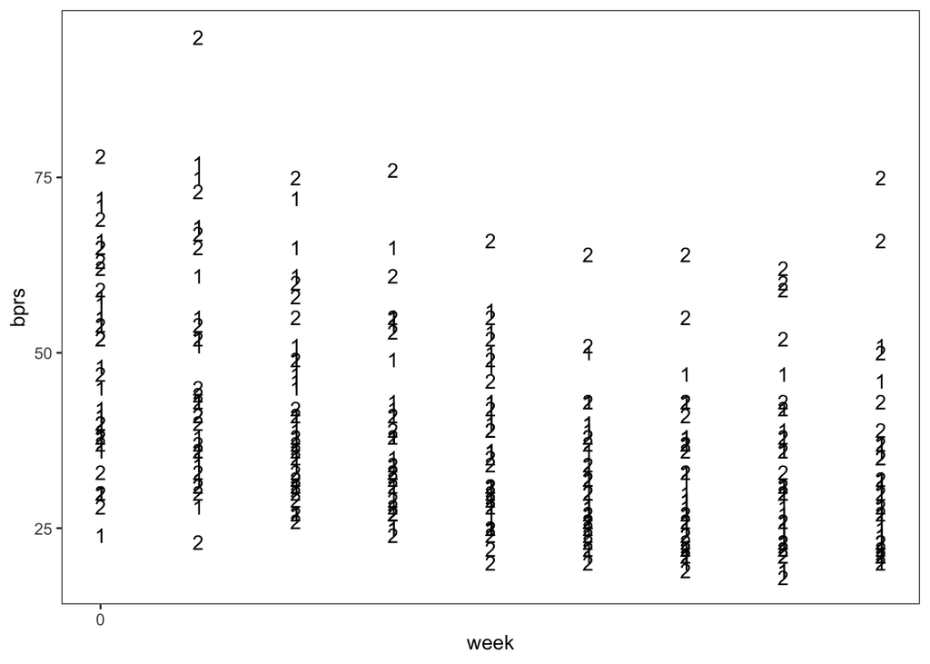

```r
p1 <- ggplot(BPRSL, aes(x = week, y = bprs, group = subject))
p2 <- p1 + geom_text(aes(label = treatment))
p3 <- p2 + scale_x_continuous(name = "week", breaks = seq(0, 60, 10))
p4 <- p3 + scale_y_continuous(name = "bprs")
p5 <- p4 + theme_bw()
p6 <- p5 + theme(panel.grid.major = element_blank(), panel.grid.minor = element_blank())
p6
```

It’s hard to make any specific inferences from this chart. Let’s move forward and represent the data with a line graph. First all, the observations in both groups tend to decrease over the treatment period. The variance in the second treatment group seems to be higher than in the first one. However, there is no an obvious difference between the BPRS of men in the group 1 and in the group 2.

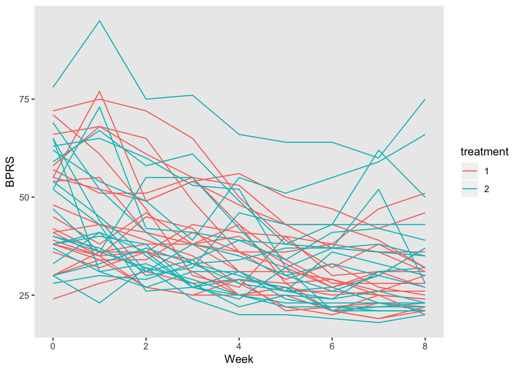

```r
p1 <- ggplot(BPRSL, aes(x = week, y = bprs, group = subject))
p2 <- p1 + geom_line(aes(color = treatment))
p3 <- p2 + scale_x_continuous(name = "Week", breaks = seq(0, 8, 2))
p4 <- p3 + scale_y_continuous(name = "BPRS")
p5 <- p4 + theme(panel.grid.major = element_blank(), panel.grid.minor = element_blank())
p5
```

In further analysis we will try to fit linear models to our data. To begin, we assume that all the observations are independent of one another and fit a **multiple linear regression model** with BPRS as response and week and treatment as explanatory variables.

```r
BPRS_reg <- lm(bprs~week+treatment, data=BPRSL)
summary(BPRS_reg)
```

```
##
## Call:
## lm(formula = bprs ~ week + treatment, data = BPRSL)
##
## Residuals:
##     Min      1Q  Median      3Q     Max
## -22.454  -8.965  -3.196   7.002  50.244
##
## Coefficients:
##             Estimate Std. Error t value Pr(>|t|)
## (Intercept)  46.4539     1.3670  33.982   <2e-16 ***
## week         -2.2704     0.2524  -8.995   <2e-16 ***
## treatment2    0.5722     1.3034   0.439    0.661
## ---
## Signif. codes:  0 '***' 0.001 '**' 0.01 '*' 0.05 '.' 0.1 ' ' 1
##
## Residual standard error: 12.37 on 357 degrees of freedom
## Multiple R-squared:  0.1851, Adjusted R-squared:  0.1806
## F-statistic: 40.55 on 2 and 357 DF,  p-value: < 2.2e-16
```

We can now see that ‘week’ is significant, but treatment is not. As we could expect, group 1 and group 2 do not differ significantly from each other conditional on time.

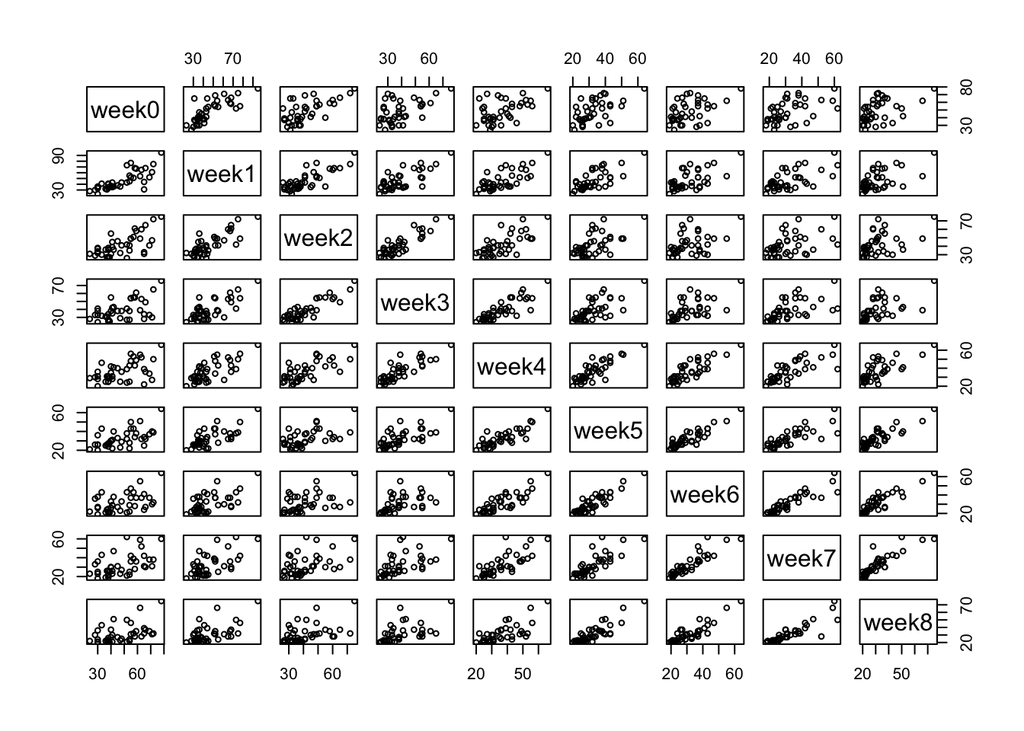

```r
pairs(BPRS[, 3:11], cex = 0.7)
```

Let’s now fit the **random intercept model** for the same two explanatory variables so that we have different intercepts for different subjects. Vertical bars (|) stand for the random-effects terms. And the theoretical model representation looks as follows:$y_{i, j} = (\beta_0 + u_i) + \beta_1 t_j + \epsilon_{i,j}$. In our case it takes form of $bprs_{i, j} = (\beta_0 + u_i) + \beta_1 week_j + \beta_2 treatment_{i,1} + \epsilon_{i,j}$, where $u_i$ is the random effect specific to the $i$th subject.

```r
library("lme4")
BPRS_ref <- lmer(bprs ~ week + treatment + (1 | subject), data = BPRSL, REML = FALSE)
summary(BPRS_ref)
```

```
## Linear mixed model fit by maximum likelihood  ['lmerMod']
## Formula: bprs ~ week + treatment + (1 | subject)
##    Data: BPRSL
##
##      AIC      BIC   logLik deviance df.resid
##   2582.9   2602.3  -1286.5   2572.9      355
##
## Scaled residuals:
##      Min       1Q   Median       3Q      Max
## -2.27506 -0.59909 -0.06104  0.44226  3.15835
##
## Random effects:
##  Groups   Name        Variance Std.Dev.
##  subject  (Intercept) 97.39    9.869
##  Residual             54.23    7.364
## Number of obs: 360, groups:  subject, 40
##
## Fixed effects:
##             Estimate Std. Error t value
## (Intercept)  46.4539     2.3521  19.750
## week         -2.2704     0.1503 -15.104
## treatment2    0.5722     3.2159   0.178
##
## Correlation of Fixed Effects:
##            (Intr) week
## week       -0.256
## treatment2 -0.684  0.000
```

Now let’s fit the **random slope model** to the BPRS dataset. And the theoretical model representation looks as follows:$y_{i, j} = (\beta_0 + u_i) + (\beta_1 +v_i) t_j + \epsilon_{i,j}$. In our case: $bprs_{i, j} = (\beta_0 + u_i) + (\beta_1 +v_i) week_j + \beta_2 treatment_{i, 1} + \epsilon_{i,j}$. This model allows the linear regression fits for each individual to differ in slope.

```r
BPRS_ref1 <- lmer(bprs ~ week + treatment + (week | subject), data = BPRSL, REML = FALSE)
summary(BPRS_ref1)
```

```
## Linear mixed model fit by maximum likelihood  ['lmerMod']
## Formula: bprs ~ week + treatment + (week | subject)
##    Data: BPRSL
##
##      AIC      BIC   logLik deviance df.resid
##   2523.2   2550.4  -1254.6   2509.2      353
##
## Scaled residuals:
##     Min      1Q  Median      3Q     Max
## -2.4655 -0.5149 -0.0920  0.4347  3.7353
##
## Random effects:
##  Groups   Name        Variance Std.Dev. Corr
##  subject  (Intercept) 167.821  12.955
##           week          2.331   1.527   -0.67
##  Residual              36.748   6.062
## Number of obs: 360, groups:  subject, 40
##
## Fixed effects:
##             Estimate Std. Error t value
## (Intercept)  45.9830     2.6469  17.372
## week         -2.2704     0.2713  -8.370
## treatment2    1.5139     3.1392   0.482
##
## Correlation of Fixed Effects:
##            (Intr) week
## week       -0.545
## treatment2 -0.593  0.000
```

The coefficient for a treatment dummy variable tripled. The likelihood ratio for the random intercept model versus the random intercept and slope model is smaller, which indicates that the model better suits the data.

```r
anova(BPRS_ref1, BPRS_ref)
```

```
## Data: BPRSL
## Models:
## BPRS_ref: bprs ~ week + treatment + (1 | subject)
## BPRS_ref1: bprs ~ week + treatment + (week | subject)
##           Df    AIC    BIC  logLik deviance  Chisq Chi Df Pr(>Chisq)
## BPRS_ref   5 2582.9 2602.3 -1286.5   2572.9
## BPRS_ref1  7 2523.2 2550.4 -1254.6   2509.2 63.663      2  1.499e-14 ***
## ---
## Signif. codes:  0 '***' 0.001 '**' 0.01 '*' 0.05 '.' 0.1 ' ' 1
```

Finally, let’s try to add an interaction term week*treatment. Explicitly, this model can be written as: $bprs_{i, j} = (\beta_0 + u_i) + (\beta_1 +v_i) week_j + \beta_2 treatment_{i, 1} + \beta_3(week_j \times treatment_{1,i}) + \epsilon_{i,j}$.

```r
BPRS_ref2 <- lmer(bprs ~ week * treatment + (week | subject), data = BPRSL, REML = FALSE)
summary(BPRS_ref2)
```

```
## Linear mixed model fit by maximum likelihood  ['lmerMod']
## Formula: bprs ~ week * treatment + (week | subject)
##    Data: BPRSL
##
##      AIC      BIC   logLik deviance df.resid
##   2523.5   2554.5  -1253.7   2507.5      352
##
## Scaled residuals:
##     Min      1Q  Median      3Q     Max
## -2.4746 -0.5254 -0.0867  0.4435  3.7883
##
## Random effects:
##  Groups   Name        Variance Std.Dev. Corr
##  subject  (Intercept) 164.176  12.813
##           week          2.203   1.484   -0.66
##  Residual              36.750   6.062
## Number of obs: 360, groups:  subject, 40
##
## Fixed effects:
##                 Estimate Std. Error t value
## (Intercept)      47.8856     2.9838  16.049
## week             -2.6283     0.3752  -7.005
## treatment2       -2.2911     4.2197  -0.543
## week:treatment2   0.7158     0.5306   1.349
##
## Correlation of Fixed Effects:
##             (Intr) week   trtmn2
## week        -0.668
## treatment2  -0.707  0.473
## wek:trtmnt2  0.473 -0.707 -0.668
## convergence code: 0
## Model failed to converge with max|grad| = 0.00704091 (tol = 0.002, component 1)
```

```r
anova(BPRS_ref1, BPRS_ref2)
```

```
## Data: BPRSL
## Models:
## BPRS_ref1: bprs ~ week + treatment + (week | subject)
## BPRS_ref2: bprs ~ week * treatment + (week | subject)
##           Df    AIC    BIC  logLik deviance Chisq Chi Df Pr(>Chisq)
## BPRS_ref1  7 2523.2 2550.4 -1254.6   2509.2
## BPRS_ref2  8 2523.5 2554.6 -1253.7   2507.5  1.78      1     0.1822
```

We can find the fitted values from the interaction model and plot the fitted BPRS for each subject.

```r
Fitted <- fitted(BPRS_ref2)
BPRSL <- BPRSL %>% mutate(Fitted)
```

It can be seen that the fitted lines are far smoother than the observed ones. This graphic underlines that the interaction model doesn’t really fits the observed data well.

```r
p1 <- ggplot(BPRSL, aes(x = week, y = bprs, group = subject))
p2 <- p1 + geom_line(aes(color = treatment))
p3 <- p2 + scale_x_continuous(name = "Week", breaks = seq(0, 8, 2))
p4 <- p3 + scale_y_continuous(name = "BPRS")
p5 <- p4 + theme_bw() + theme(legend.position = "right") # "none" in the book
p6 <- p5 + theme(panel.grid.major = element_blank(), panel.grid.minor = element_blank())
p7 <- p6 + ggtitle("Observed")
graph1 <- p7
```

```r
p1 <- ggplot(BPRSL, aes(x = week, y = Fitted, group = subject))
p2 <- p1 + geom_line(aes(color = treatment))
p3 <- p2 + scale_x_continuous(name = "Week", breaks = seq(0, 8, 2))
p4 <- p3 + scale_y_continuous(name = "BPRS")
p5 <- p4 + theme_bw() + theme(legend.position = "right")
p6 <- p5 + theme(panel.grid.major = element_blank(), panel.grid.minor = element_blank())
p7 <- p6 + ggtitle("Fitted")
graph2 <- p7
```

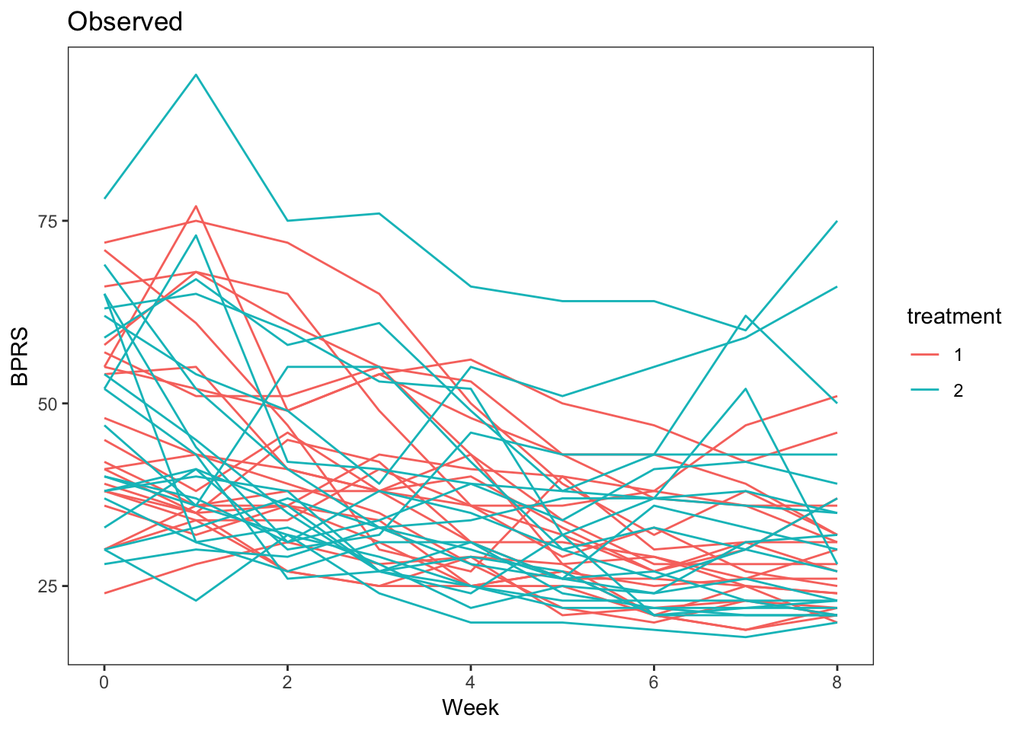

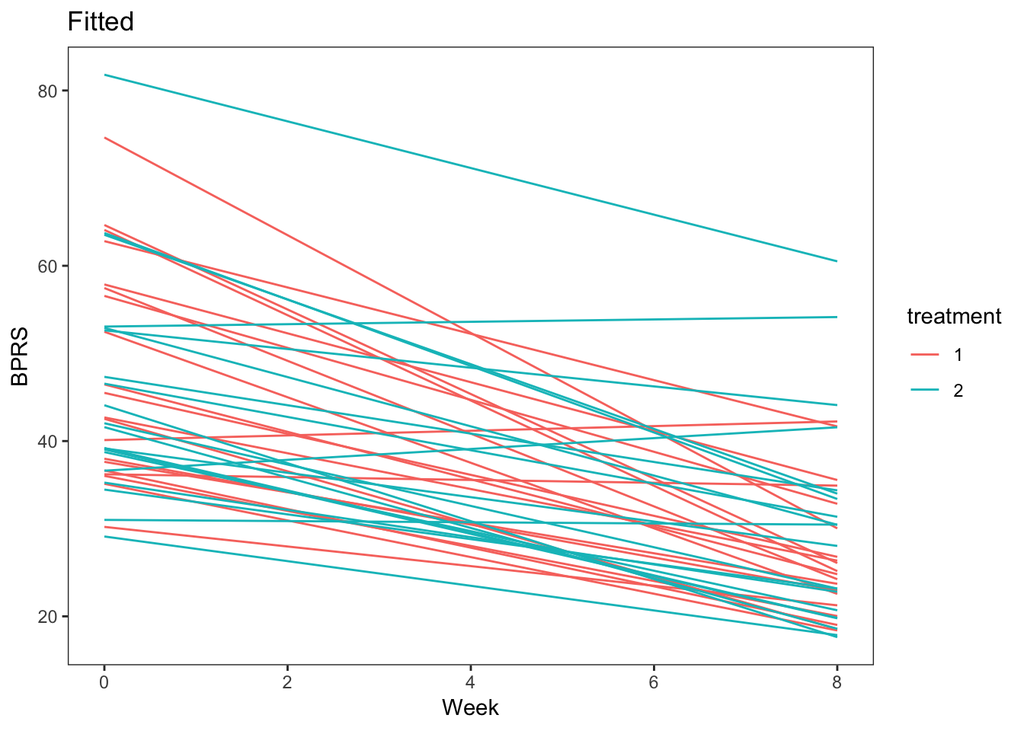

```r
graph1; graph2
```

**That’s the end!** 🥳 🤩 🎉